# EEE933 - Estudo de Caso 01: Comparação do IMC médio de alunos do PPGEE-UFMG entre os semestres 2016-2 e 2017-2

Amanda Bomfim Moitinho, David Felipe Brochero Giraldo, Henrique Marques Cruz

13/09/2026

## Resumo

Este estudo compara o IMC médio de alunos de pós-graduação do PPGEE-UFMG entre os semestres 2016-2 e 2017-2, com a análise estratificada por sexo. Foram conduzidos testes $t$ de Welch para duas amostras independentes, com verificação de premissas (normalidade via Shapiro-Wilk, homogeneidade de variância via Fligner-Killeen) e teste de Wilcoxon como checagem de robustez. Nenhum dos grupos apresentou diferença estatisticamente significativa ao nível $\alpha = 0.05$ ($p = 0.060$ para mulheres, $p = 0.593$ para homens), mas a potência a priori para detectar um efeito mínimo relevante de $\delta^* = 1.0 kg/m^2$ é baixa nos dois grupos, $\approx 10.9\%$ nas mulheres ($n=7$ e $n=4$) e $\approx 12.5\%$ nos homens ($n=21$ em cada semestre), sendo esta última penalizada pelo desvio-padrão do IMC masculino ($\approx 3.90$) ser quase o dobro do feminino ($\approx 2.05$). Ambos os resultados são, portanto, inconclusivos quanto à existência de uma diferença de pelo menos 1.0$ $kg/m^2$ entre os semestres.

## Desenho experimental

### Descrição do problema

O objetivo é comparar o IMC médio de duas populações de estudantes, usando o IMC como *proxy* para variáveis relativas ao estilo de vida. As amostras consistem em dados de peso, altura e sexo de alunos de pós-graduação em Engenharia Elétrica da UFMG nos semestres 2016-2 e 2017-2.

### Hipóteses

A amostra foi estratificada por sexo e dois testes independentes foram conduzidos, um para cada subpopulação:

$$\text{Mulheres:}\quad\begin{cases} H_0:
\mu_{F,2016} = \mu_{F,2017}\\ H_1: \mu_{F,2016} \neq
\mu_{F,2017}\end{cases} \qquad
\text{Homens:}\quad\begin{cases} H_0: \mu_{M,2016} = \mu_{M,2017}\\ H_1:
\mu_{M,2016} \neq \mu_{M,2017}\end{cases}$$

Foram utilizadas hipóteses bilaterais por não haver razão a priori para esperar que o IMC tenha subido ou descido de um semestre para o outro. O nível de significância adotado é $\alpha = 0.05$ por teste. Como são dois testes independentes (um por sexo), o erro tipo I por família é maior que 5% ($\approx 1 - (1-0.05)^2 = 9.75\%$ sob independência); tratamos cada estrato como pergunta separada e reportamos os $p$-valores brutos, notando que uma correção de Bonferroni ($\alpha = 0.025$ por teste) não alteraria as conclusões deste caso.

### Tamanho de efeito mínimo relevante ($\delta^*$)

Como não há consenso sobre uma diferença mínima clinicamente importante (MCID, do inglês *Minimal Clinically Important Difference*) para IMC nesse contexto, adotamos $\delta^* = 1.0$ $kg/m^2$ com base nos estudos [1], [2] e [3], que associam a variação de 1 unidade de IMC a mudanças na qualidade de vida relacionada à saúde. Esses estudos foram conduzidos em populações com obesidade ou em contextos de intervenção de perda de peso, e que MCID descreve tipicamente mudança intraindividual ao longo do tempo, condições que provavelmente não se aplicam diretamente à população deste estudo, majoritariamente composta por adultos sem diagnóstico de obesidade. O valor é portanto utilizado como aproximação conservadora para ancorar a análise de potência *a priori*, e não como estimativa específica para esta população.

```r
mcid <- 1.0  # delta* (MCID) adotado, em kg/m^2
```

### Descrição da coleta e consolidação dos dados

Os dois arquivos fornecidos têm formatos diferentes, exigindo consolidação:

- `imc_20162.csv`: separado por vírgula, colunas `ID, Course, Gender, Height.m, Weight.kg`. Contém alunos de dois cursos (PPGEE e ENGSIS/graduação); os registros de ENGSIS foram excluídos, pois o escopo do estudo é a pós-graduação em Engenharia Elétrica.
- `CS01_20172.csv`: separado por ponto-e-vírgula, colunas `Weight.kg, height.m, Sex, Age.years` (sem coluna de curso e sem ID, mas com idade).

**Suposição explícita:** como o arquivo de 2017-2 não tem coluna de curso e o enunciado só menciona mistura de turmas para o arquivo de 2016-2, assumimos que todos os registros de `CS01_20172.csv` já são de alunos do PPGEE.

**Limitação quanto à independência:** o arquivo de 2017-2 não inclui identificação individual, de modo que não é possível verificar se algum aluno aparece nos dois semestres. Em um mesmo programa, essa sobreposição tende a ocorrer entre os alunos matrículados em anos consecutivos, o que compromete a premissa de independência entre as amostras: como as medições do mesmo indivíduo são positivamente correlacionadas, o teste $t$ de duas amostras (que assume independência) superestima o erro padrão da diferença de médias, tornando o teste mais conservador do que deveria.

```r
d16 <- read.csv("imc_20162.csv", stringsAsFactors = FALSE)
d17 <- read.csv("CS01_20172.csv", sep = ";", stringsAsFactors = FALSE)

d16 <- d16[d16$Course == "PPGEE", ]

d16$IMC <- d16$Weight.kg / (d16$Height.m^2)
d17$IMC <- d17$Weight.kg / (d17$height.m^2)

df <- data.frame(
  Semestre = factor(c(rep("2016-2", nrow(d16)), rep("2017-2", nrow(d17))),
                     levels = c("2016-2", "2017-2")),
  Sexo     = factor(c(d16$Gender, d17$Sex), levels = c("F", "M"),
                     labels = c("Feminino", "Masculino")),
  Altura   = c(d16$Height.m, d17$height.m),
  Peso     = c(d16$Weight.kg, d17$Weight.kg),
  IMC      = c(d16$IMC, d17$IMC)
)
```

## Análise Exploratória

A Tabela 1 mostra a distribuição de observações por grupo e por semestre.

Número de observações por grupo

|  | Feminino | Masculino |
| --- | --- | --- |
| 2016-2 | 7 | 21 |
| 2017-2 | 4 | 21 |

O grupo feminino de 2017-2 possui apenas 4 observações, bem menos que os demais grupos (7, 21 e 21). Isso consiste em um sinal de alerta para a potência do teste correspondente.

A Tabela 2 resume as estatísticas descritivas do IMC por grupo.

Estatísticas descritivas do IMC por grupo

| Semestre | Sexo | n | Media | DP | Mediana |
| --- | --- | --- | --- | --- | --- |
| 2016-2 | Feminino | 7 | 21.08 | 2.42 | 20.20 |
| 2017-2 | Feminino | 4 | 18.45 | 1.60 | 17.80 |
| 2016-2 | Masculino | 21 | 24.94 | 4.32 | 24.36 |
| 2017-2 | Masculino | 21 | 24.29 | 3.44 | 23.75 |

A Figura 1 ilustra a distribuição do IMC por semestre, separada por sexo.

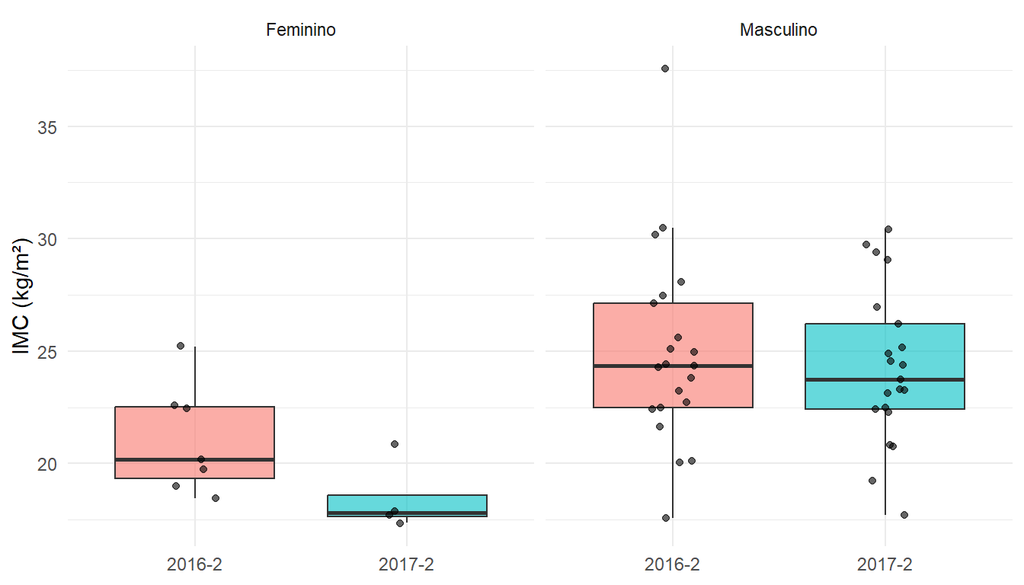

IMC por semestre, separado por sexo

```r
ggplot(df, aes(x = Semestre, y = IMC, fill = Semestre)) +
  geom_boxplot(alpha = 0.6, outlier.shape = NA) +
  geom_jitter(width = 0.1, alpha = 0.6) +
  facet_wrap(~ Sexo) +
  labs(y = "IMC (kg/m²)", x = NULL) +
  theme_minimal() +
  theme(legend.position = "none")
```

O IMC médio feminino aparenta cair de 2016-2 para 2017-2, enquanto o masculino se mantém aparentemente estável. A dispersão é visivelmente maior no grupo masculino, e o grupo feminino de 2017-2 tem poucos pontos e pouca variabilidade aparente. Contudo, tais observações podem ser efeito do $n$ pequeno.

## Análise Estatística

### Testes de hipóteses, tamanho de efeito e intervalo de confiança

```r
cohend <- function(x, y) {
  nx <- length(x); ny <- length(y)
  sp <- sqrt(((nx - 1) * var(x) + (ny - 1) * var(y)) / (nx + ny - 2))
  (mean(x) - mean(y)) / sp
}
```

```r
xF16 <- df$IMC[df$Sexo == "Feminino" & df$Semestre == "2016-2"]
xF17 <- df$IMC[df$Sexo == "Feminino" & df$Semestre == "2017-2"]
tF <- t.test(xF16, xF17)
tF
```

```
##
##  Welch Two Sample t-test
##
## data:  xF16 and xF17
## t = 2.17, df = 8.5966, p-value = 0.0595
## alternative hypothesis: true difference in means is not equal to 0
## 95 percent confidence interval:
##  -0.1318507  5.4075232
## sample estimates:
## mean of x mean of y
##  21.08443  18.44660
```

```r
dF <- cohend(xF16, xF17)
cat("Cohen's d =", round(dF, 2), "\n")
```

```
## Cohen's d = 1.21
```

```r
wF <- wilcox.test(xF16, xF17)
wF
```

```
##
##  Wilcoxon rank sum exact test
##
## data:  xF16 and xF17
## W = 24, p-value = 0.07273
## alternative hypothesis: true location shift is not equal to 0
```

```r
xM16 <- df$IMC[df$Sexo == "Masculino" & df$Semestre == "2016-2"]
xM17 <- df$IMC[df$Sexo == "Masculino" & df$Semestre == "2017-2"]
tM <- t.test(xM16, xM17)
tM
```

```
##
##  Welch Two Sample t-test
##
## data:  xM16 and xM17
## t = 0.53979, df = 38.057, p-value = 0.5925
## alternative hypothesis: true difference in means is not equal to 0
## 95 percent confidence interval:
##  -1.788823  3.089716
## sample estimates:
## mean of x mean of y
##  24.93595  24.28551
```

```r
dM <- cohend(xM16, xM17)
cat("Cohen's d =", round(dM, 2), "\n")
```

```
## Cohen's d = 0.17
```

```r
wM <- wilcox.test(xM16, xM17)
wM
```

```
##
##  Wilcoxon rank sum exact test
##
## data:  xM16 and xM17
## W = 236, p-value = 0.7088
## alternative hypothesis: true location shift is not equal to 0
```

O teste $t$ de **Welch** foi utilizado como teste principal por ser mais robusto a diferenças de variância entre grupos, enquanto que o teste de Wilcoxon foi incluso como checagem de robustez sob possíveis violações de normalidade.

### Potência do teste

A potência é calculada para o $\delta^*$ definido a priori na seção de Desenho experimental.

```r
sdF <- sqrt((var(xF16) + var(xF17)) / 2)
sdM <- sqrt((var(xM16) + var(xM17)) / 2)
nF  <- mean(c(length(xF16), length(xF17)))
nM  <- length(xM16)

potF  <- power.t.test(n = nF, delta = mcid, sd = sdF, sig.level = 0.05)
potM  <- power.t.test(n = nM, delta = mcid, sd = sdM, sig.level = 0.05)
npotF <- power.t.test(delta = mcid, sd = sdF, sig.level = 0.05, power = 0.80)
npotM <- power.t.test(delta = mcid, sd = sdM, sig.level = 0.05, power = 0.80)

potF; potM; npotF; npotM
```

```
##
##      Two-sample t test power calculation
##
##               n = 5.5
##           delta = 1
##              sd = 2.051034
##       sig.level = 0.05
##           power = 0.1085384
##     alternative = two.sided
##
## NOTE: n is number in *each* group
```

```
##
##      Two-sample t test power calculation
##
##               n = 21
##           delta = 1
##              sd = 3.904637
##       sig.level = 0.05
##           power = 0.1250999
##     alternative = two.sided
##
## NOTE: n is number in *each* group
```

```
##
##      Two-sample t test power calculation
##
##               n = 67.01045
##           delta = 1
##              sd = 2.051034
##       sig.level = 0.05
##           power = 0.8
##     alternative = two.sided
##
## NOTE: n is number in *each* group
```

```
##
##      Two-sample t test power calculation
##
##               n = 240.2951
##           delta = 1
##              sd = 3.904637
##       sig.level = 0.05
##           power = 0.8
##     alternative = two.sided
##
## NOTE: n is number in *each* group
```

Para o grupo **feminino**, a potência para detectar $\delta^* = 1$ kg/m² é de apenas $10.9\%$, com $n=7$ e $n=4$. Seriam necessárias $\approx$ 68 observações por semestre para atingir 80% de potência nesse efeito. A não-rejeição de $H_0$ é, portanto, inconclusiva quanto a um efeito do tamanho do $\delta^*$.

Para o grupo **masculino**, apesar de $n=21$ em cada semestre, a potência para o mesmo $\delta^*$ é de apenas $12.5\%$. Seriam necessárias ainda cerca de 241 observações por semestre para atingir 80% de potência, bem mais que o exigido no grupo feminino, visto que o desvio-padrão do IMC masculino ($3.9$) é quase o dobro do feminino ($2.05$). Ou seja, o $n=21$ por grupo definido no desenho original, que era aparentemente razoável, não bastou para detectar o o efeito mínimo relevante $\delta^*$ pré-especificado.

### Verificação das premissas

Embora o teste $t$ de Welch seja razoavelmente robusto a pequenos desvios das premissas de normalidade e igualdade de variâncias, verificamos essas premissas para assegurar que as condições do teste são razoáveis nos dados observados. Como discutido na seção de Desenho, a sobreposição de alunos entre os dois semestres é plausível e comprometeria a validade dos testes, tornando-os mais conservadores.

A Tabela 3 apresenta os resultados do teste de Shapiro-Wilk para normalidade em cada grupo.

```r
grupos <- expand.grid(Sexo = levels(df$Sexo), Semestre = levels(df$Semestre))
sw <- apply(grupos, 1, function(g) {
  x <- df$IMC[df$Sexo == g["Sexo"] & df$Semestre == g["Semestre"]]
  s <- shapiro.test(x)
  data.frame(Sexo = g["Sexo"], Semestre = g["Semestre"], n = length(x),
             W = round(s$statistic, 3), p_valor = round(s$p.value, 3))
})
knitr::kable(do.call(rbind, sw), row.names = FALSE,
             caption = "Teste de Shapiro-Wilk por grupo")
```

Teste de Shapiro-Wilk por grupo

| Sexo | Semestre | n | W | p_valor |
| --- | --- | --- | --- | --- |
| Feminino | 2016-2 | 7 | 0.920 | 0.467 |
| Masculino | 2016-2 | 21 | 0.928 | 0.127 |
| Feminino | 2017-2 | 4 | 0.747 | 0.037 |
| Masculino | 2017-2 | 21 | 0.965 | 0.621 |

O único grupo em que a normalidade é rejeitada a 5% é o feminino de 2017-2 ($p = 0.037$). Porém, com $n=4$, o teste de Shapiro-Wilk tem potência baixa para detectar não-normalidade, e o resultado deve ser lido em conjunto com cautela, visto que não confirma nem descarta a suposição de normalidade.

```r
fligner.test(IMC ~ Semestre, data = df[df$Sexo == "Feminino", ])
```

```
##
##  Fligner-Killeen test of homogeneity of variances
##
## data:  IMC by Semestre
## Fligner-Killeen:med chi-squared = 0.71101, df = 1, p-value = 0.3991
```

```r
fligner.test(IMC ~ Semestre, data = df[df$Sexo == "Masculino", ])
```

```
##
##  Fligner-Killeen test of homogeneity of variances
##
## data:  IMC by Semestre
## Fligner-Killeen:med chi-squared = 0.082824, df = 1, p-value = 0.7735
```

Nenhum dos testes de Fligner-Killeen rejeita igualdade de variâncias, o que é consistente com a escolha do teste $t$ de Welch utilizado anteriormente. Por ser mais robusto e ter perda de potência pequena quando as variâncias são de fato iguais, essa escolha permanece adequada independentemente do resultado desta checagem.

Nesse contexto, selecionar entre o teste de Student e o de Welch com base no resultado de um teste prévio de igualdade de variâncias é desaconselhado na literatura, por distorcer a taxa de erro tipo I nominal do teste final [4].

### Referências

[1] Kral P, Holst-Hansen T, Olivieri AV, Ivanescu C, et al. The Correlation Between Body Mass Index and Health-Related Quality of Life: Data from Two Weight Loss Intervention Studies. Adv Ther. 2024;41:4228–4247. https://doi.org/10.1007/s12325-024-02932-8

[2] Steele RG, Gayes LA, Dalton WT, Smith C, Maphis L, Conway-Williams E. Change in health-related quality of life in the context of pediatric obesity interventions: A meta-analytic review. Health Psychol. 2016;35(10):1097-1109. https://doi.org/10.1037/hea0000362

[3] Hakim Z, Wolf A, Garrison LP. Estimating the effect of changes in body mass index on health state preferences. Pharmacoeconomics. 2002;20(6):393-404. https://doi.org/10.2165/00019053-200220060-00004

[4] Delacre M, Lakens D, Leys C. Why Psychologists Should by Default Use Welch’s t-test Instead of Student’s t-test. Int Rev Soc Psychol. 2017;30(1):92-101. https://doi.org/10.5334/irsp.82 (ver errata: Delacre M, Lakens D, Leys C. Correction… Int Rev Soc Psychol. 2022;35(1):21. https://doi.org/10.5334/irsp.661, não altera a conclusão principal)

### Papéis da equipe

- Amanda Bomfim Moitinho: Verificadora
- David Felipe Brochero Giraldo: Relator
- Henrique Marques Cruz: Relator

### Declaração sobre o uso de IA generativa e tecnologias assistidas por IA

Durante a preparação deste trabalho, os autores utilizaram o assistente de IA Claude (Anthropic) para apoiar a estruturação do código de análise estatística em R. Após o uso dessa ferramenta, os autores revisaram e editaram o conteúdo conforme necessário e assumem total responsabilidade pelo conteúdo do relatório.